# Homework of all time

SA23204185

2023-12-10

## Homework 1

### Example 1

We will realize the IPW algorithm in Cho(2017).

Don’t worry too much about this piece of code. In fact, I’ve been working on replicating an article during this period. Treat it as inputting a matrix $M$, and it will give you back a $U$ and $V$.

```r
IPW <- function(M, K=2) {
  n <- nrow(M)
  d <- ncol(M)
  Y <- ifelse(M == 0, 0, 1)  # 使用向量化操作代替循环

  p_hat <- sum(Y) / (n * d)

  Sigma_phat <- crossprod(M) - (1 - p_hat) * diag(colSums(M^2))
  Sigma_tphat <- crossprod(t(M)) - (1 - p_hat) * diag(rowSums(M^2))


  eigen_Sigma_phat <- eigen(Sigma_phat)
  eigen_Sigma_tphat <- eigen(Sigma_tphat)

  # 得到分解
  V <- eigen_Sigma_phat$vectors[, 1:K]
  lambda_hat <- sqrt(eigen_Sigma_phat$values[1:K] - sum(eigen_Sigma_phat$values[(K+1):d]) / (d - K -1)) / p_hat
  U <- eigen_Sigma_tphat$vectors[, 1:K]

  return(list(V = V, U = U, lambda_hat = lambda_hat))
}
```

We will give out a $M$ to try it.

```r
initial<-function(n,d){
  A <- matrix(runif(n * 2, min = -5, max = 5), n, 2)
  B <- matrix(runif(d * 2, min = -5, max = 5), d, 2)
  M0 <- A%*%t(B)

  return(M0)
}
```

```r
#xtable::xtable(IPW(initial(n = 10, d = 2))$V)
```

### Example 2

```r
IPW(initial(n = 10, d = 2))$U
```

[output not shown]

### Example 3

- We will write down the Thereom 1 in Cho(2017), so we have mathematical formulas.

$$\begin{align*}
& \mathbb{E}\left\|\sin \left(\hat{V}^{(m)},
V^{(m)}\right)\right\|_{F}^{2} \leq \frac{C_{1}
n^{-1}}{p\left(b_{m}^{2}-b_{m+1}^{2}\right)^{2}} \\
\end{align*}$$

## Homework 2

### Question 1

- Reproduce part of the functionality of the sample function using the inverse transform method, with replace=TRUE.

### Answer

- Considering the code provided in the PDF, we have:

```r
my_sample <- function(values, n, probabilities = rep(1/length(values), length(values))) {
  # Compute the cumulative distribution function
  cdf <- cumsum(probabilities)

  # Generate random numbers
  samples <- numeric(n)
  for (i in 1:n) {
    u <- runif(1)
    samples[i] <- values[findInterval(u, cdf)+1]
  }

  return(samples)
}
```

- Here is a practical example to demonstrate that we have replicated part of the functionality of the sample function.

```r
# Initialize the values to be sampled and the sample size
values <- 1:10
n <- 10

random_samples <- my_sample(values, n)
print(random_samples)
```

```
##  [1] 6 3 9 8 6 2 5 8 7 9
```

### Question 2

- Exercises 3.2 (Statistical Computing with R)

### Answer

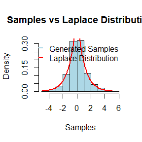

```r
# Generate random samples from the standard Laplace distribution using the inverse transform method
inverse_sample_laplace <- function(n) {
  u <- runif(n)
  samples <- ifelse(u < 0.5, log(2 * u), -log(2 - 2 * u))
  return(samples)
}

# Generate 1000 random samples from the standard Laplace distribution
n <- 1000
laplace_samples <- inverse_sample_laplace(n)

# Plot the histogram of the generated samples
hist(laplace_samples, freq = FALSE, main = "Samples vs Laplace Distribution",
     xlab = "Samples", ylab = "Density", col = "lightblue")

# Plot the density function curve of the standard Laplace distribution
x <- seq(-5, 5, length.out = 100)
density_laplace <- 0.5 * exp(-abs(x))
lines(x, density_laplace, col = "red", lwd = 2)

# Add a legend
legend("topright", legend = c("Generated Samples", "Laplace Distribution"),
       col = c("lightblue", "red"), lwd = 2, bty = "n")
```

- From the above plot, we can observe that we have successfully generated samples that follow the Laplace distribution using the inverse transform method.

### Question 3

- Exercises 3.7 (Statistical Computing with R)

### Answer

```r
# Rejection sampling to generate random samples from the beta distribution
generate_beta_sample <- function(n, a, b) {
  # Let g(x) = 1, 0 < x < 1 and M = max(a, b) + 1.
  samples <- numeric(n)
  count <- 0
  M <- max(a, b) + 1

  while (count < n) {
    u <- runif(1)
    x <- runif(1)

    if (dbeta(x, a, b) > M*u) {
      samples[count + 1] <- x
      count <- count + 1
    }
  }

  return(samples)
}
```

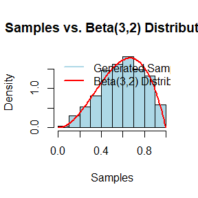

```r
# Generate random samples from the Beta(3, 2) distribution
n <- 1000
a <- 3
b <- 2
beta_samples <- generate_beta_sample(n, a, b)

# Plot the histogram of the generated samples
hist(beta_samples, freq = FALSE, main = "Samples vs. Beta(3,2) Distribution",
     xlab = "Samples", ylab = "Density", col = "lightblue")

# Plot the density function curve of the Beta(3, 2) distribution
x <- seq(0, 1, length.out = 100)
density_beta <- dbeta(x, a, b)
lines(x, density_beta, col = "red", lwd = 2)

# Add a legend
legend("topleft", legend = c("Generated Samples", "Beta(3,2) Distribution"),
       col = c("lightblue", "red"), lwd = 2, bty = "n")
```

- From the plot above, we can observe that we have successfully generated samples that follow the Beta(3, 2) distribution using the rejection sampling method.

### Question 4

- Exercises 3.9 (Statistical Computing with R)

### Answer

```r
# Generate samples using the method described in the question
generate_epanechnikov_sample <- function(n) {
  samples <- numeric(n)

  for (i in 1:n) {
    U1 <- runif(1, -1, 1)
    U2 <- runif(1, -1, 1)
    U3 <- runif(1, -1, 1)

    if (abs(U3) >= abs(U2) && abs(U3) >= abs(U1)) {
      samples[i] <- U2
    } else {
      samples[i] <- U3
    }
  }

  return(samples)
}
```

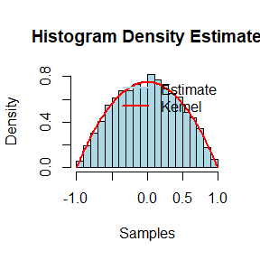

```r
# Generate a large number of simulated random samples
n <- 10000
epanechnikov_samples <- generate_epanechnikov_sample(n)

# Construct a histogram density estimate
hist(epanechnikov_samples, prob = TRUE, main = "Histogram Density Estimate",
     xlab = "Samples", ylab = "Density", col = "lightblue")

# Construct a histogram density estimate
x <- seq(-1, 1, length.out = 100)
density_epanechnikov <- 3/4 * (1 - x^2)
lines(x, density_epanechnikov, col = "red", lwd = 2)

# Add a legend
legend("topright", legend = c("Estimate", "Kernel"),
       col = c("lightblue", "red"), lwd = 2, bty = "n")
```

- From the plot above, we can observe that we have successfully generated samples that follow the Epanechnikov kernel density function using the method described in the question.

### Question 5

- Exercises 3.10 (Statistical Computing with R)

## Homework 3

### Question 1

- 关于 Buffon’s Needle Experiment：
  - 找一个最优的$\frac{l}{d}$，使得$\hat{\pi} = \frac{2l}{d\hat{p}}$，$\hat{p}=\frac{n}{m}$ 的渐近方差最小($\Delta$方法，$n$~$B(m,p)$)，记最优的$\rho$为$\rho_{min}$。
  - 取三个不同的$\rho$($0 \le \rho \le 1$，其中一个为$\rho_{min}$)
    - 如$\rho_{min} = 1$， 取另外两个$\rho$为0.5和0.8。
    - 如$\rho_{min} < 1$，取另外两个$\rho$为$\frac{\rho_{min}}{2}$和1。 用MC方法比较三个$rho$之下的$\hat{\pi}$的方差（取$m = 10^6$, $Monte = 100$)

### Answer

- 我们首先回答第一个问题，以下运用$\Delta$方法： 令$\hat{\pi} = f_{\pi}(\hat{p})$， 其中$f_{\pi}(x) := \frac{2\rho}{x}$

现在，我们知道$m\hat{p}$ ~ $B(m,p)$ ，显然有$E(\hat{p}) = p$，$Var(\hat{p}) = \frac{p(1-p)}{m}$

所以根据$\Delta$方法，我们有

$$Var(\hat{\pi}) \approx f_{\pi}^{'2}(p) Var(\hat{p})$$

所以$Var(\hat{\pi}) \approx 4\frac{1-p}{mp^3}\rho^2$，且$p = \frac{2\pi}{\rho}$，代入我们有：

$$Var(\hat{\pi}) \approx \frac{\pi^{3}}{2m}(\frac{1}{\rho} -
\frac{2}{\pi})$$

又$\rho \in (0,1]，$所以当$\rho = 1$，$\hat{\pi}$方差最小。

- 我们现在回答第二个问题，用MC方法比较

```r
# 构造pi_hat的输出函数
var_pi <- function(rho, seed = 1) {
  set.seed(seed)
  # 直接假定d = 1 ，则此时l = rho
  m <- 1e6
  X <- runif(m, 0, 1 / 2)
  Y <- runif(m, 0, pi / 2)
  pihat <- 2 * rho / mean(rho / 2 * sin(Y) > X)
}
```

```r
# 构造函数，使得得到多个pi_hat以计算方差
var_pi_monte <- function(rho, monte) {
  var_pi_result <- sapply(1:monte, function(i) var_pi(rho, i))
  return(round(var(var_pi_result),6))
}
```

```r
rho_values <- c(0.5, 0.8, 1)
results <- sapply(rho_values, var_pi_monte, monte = 100)
message(paste("当分别代入", paste(rho_values, collapse = ", "), "时，我们有方差分别为:", paste(results, collapse = ", ")))
```

```
## 当分别代入 0.5, 0.8, 1 时，我们有方差分别为: 1.8e-05, 8e-06, 4e-06
```

显然，随着$\rho$的增加，方差在减小。且$\rho = 1$时方差最小，符合我们的理论计算。

### Question 2

- Question for 5.6

### Question 3

- Question for 5.7

### Answer

```r
m <- 1e3

# 创建估计函数，输出theta_hat的估计，theta_hat的antithetic估计，和真实的theta
estimate <- function() {
  x <- runif(m, min = 0, max = 1)
  theta_hat <- mean(exp(x))  # Simple Monte Carlo method
  x1 <- runif(m / 2, min = 0, max = 1)
  theta_hat_antithetic <- (mean(exp(x1))+mean(exp(1-x1)))/2  # Antithetic variate approach
  true <- exp(1) - 1
  c(theta_hat, theta_hat_antithetic, true)
}

# 重复以便计算出方差
result <- replicate(1000, estimate())
var_simple <- var(result[1, ])
var_antithetic <- var(result[2, ])
percent_reduction_var <- (var_simple - var_antithetic) / var_simple

# 输出方差及其减少百分比
output <- paste(" Simple Monte Carlo method:", var_simple, "\n",
                "Antithetic variate approach:", var_antithetic, "\n",
                "Empirical estimate of the percent reduction:", percent_reduction_var, "\n",
                "True percent reduction:", (exp(2) - 2 * exp(1) - 1) / (-2 * exp(2) + 8 * exp(1) - 6))

cat(output)
```

```
##  Simple Monte Carlo method: 0.000232501873781929
##  Antithetic variate approach: 7.84235673537265e-06
##  Empirical estimate of the percent reduction: 0.966269705238039
##  True percent reduction: 0.983835035717261
```

可见模拟的减少比例和真实比例非常接近。

```r
data <- c(2.14, 2.10, 2.13, 2.15, 2.13, 2.12, 2.13, 2.10,
          2.15, 2.12, 2.14, 2.10, 2.13, 2.11, 2.14, 2.11)

var(data)
```

```
## [1] 0.0002933333
```

## Homework 4

### Question 1

- $\operatorname{Var}\left(\hat{\theta}^{M}\right)=\operatorname{Var}\left(\hat{\theta}^{S}\right)+\operatorname{Var}\left(\theta_{I}\right), \text { where } \theta_{i}=E[g(U) \mid I=i], \sigma_{i}^{2}=\operatorname{Var}[g(U) \mid I=i]$, and I takes uniform distribution over $\{1, \ldots, k\}$ .
- Proof that if g is a continuous function over (a, b) , then $\operatorname{Var}\left(\hat{\theta}^{S}\right) / \operatorname{Var}\left(\hat{\theta}^{M}\right) \rightarrow 0$ as $b_{i}-a_{i} \rightarrow 0$ for all $i=1, \ldots, k.$

### Answer

- 事实上，我们知道题目等价于只需证明:

$$lim_{k \to \infty}
\frac{M\operatorname{Var}\left(\hat{\theta}^{S}\right)}{\operatorname{Var}\left(\theta_{I}\right)}=
\frac{E[Var(g(U |J)]}{Var(E[g(U |J)]} \to 0$$

当$k \to \infty$，这显然成立。

### Question 2

- Question for 5.13

### Answer

```r
library(bayesmeta)  # 引入 bayesmeta 包，用于生成瑞利分布
```

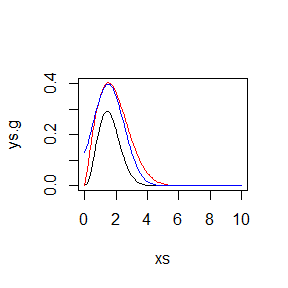

```r
# 定义函数 g(x)
g <- function(x) {
  x^2 / sqrt(2*pi) * exp(-x^2/2)
}

xs <- seq(0, 10, 0.1)  # 生成从 0 到 10，步长为 0.1 的序列作为 x 值

# 计算函数 g(x) 在 xs 上的取值
ys.g <- g(xs)

# 生成瑞利分布在 xs 上的取值，其中 scale 参数为 1.5
ys.rayleigh <- drayleigh(xs, scale = 1.5)

# 生成正态分布在 xs 上的取值，其中 mean 参数为 1.5
ys.norm <- dnorm(xs, mean = 1.5)

lim <- max(c(ys.g, ys.rayleigh, ys.norm))  # 计算三个函数的取值的最大值

# 绘制函数曲线
plot(xs, ys.g, type = "l", ylim = c(0, lim))  # 绘制函数 g(x) 的曲线，y 轴范围为 0 到 lim
lines(xs, ys.rayleigh, col = "red", ylim = c(0, lim))  # 绘制瑞利分布的曲线，颜色为红色，y 轴范围为 0 到 lim
lines(xs, ys.norm, col = "blue", ylim = c(0, lim))  # 绘制正态分布的曲线，颜色为蓝色，y 轴范围为 0 到 lim
```

- $f_{1}(x) = drayleigh(x, scale = 1.5)$，$f_{2}(x) = dnorm(x, mean = 1.5)$。而$f_{2}$ 距离$g$更近，效果应该更好。

### Question 3

- Question for 5.14

### Answer

```r
M <- 1e4  # 总样本量

# 定义函数 g(x)
g <- function(x) {
  x^2 / sqrt(2*pi) * exp(-x^2/2) * (x > 1)
}

# 定义函数 f1(x)
f1 <- function(x) {
  drayleigh(x, scale = 1.5) * (x > 1)
}

# 定义函数 f2(x)
f2 <- function(x) {
  dnorm(x, mean = 1.5) * (x > 1)
}

# 定义函数 rf1()，生成服从瑞利分布的随机样本
rf1 <- function() {
  rrayleigh(M, scale = 1.5)
}

# 定义函数 rf2()，生成服从正态分布的随机样本
rf2 <- function() {
  rnorm(M, mean = 1.5)
}

# 定义函数 is.rayleigh()，估计瑞利分布的参数 theta1
is.rayleigh <- function() {
  xs <- rf1()  # 生成瑞利分布的随机样本
  mean(g(xs)/f1(xs), na.rm = TRUE)  # 计算估计值，取平均并忽略缺失值
}

# 定义函数 is.norm()，估计正态分布的参数 theta2
is.norm <- function() {
  xs <- rf2()  # 生成正态分布的随机样本
  mean(g(xs)/f2(xs), na.rm = TRUE)  # 计算估计值，取平均并忽略缺失值
}

theta1 <- is.rayleigh()  # 估计瑞利分布的参数 theta1
theta2 <- is.norm()  # 估计正态分布的参数 theta2

theta1  # 打印估计的瑞利分布参数 theta1
```

```
## [1] 0.5025711
```

```r
theta2  # 打印估计的正态分布参数 theta2
```

```
## [1] 0.5765356
```

### Question 4

- Question for 5.15

### Answer

```r
M <- 1e4  # 总样本量
N <- 1000  # 重复次数
k <- 5  # 分层数

# 逆变换方法生成密度函数为 f_k(x) 的随机数
# 注意 (a, b) 对应不同层的密度函数
inv_fun <- function(n, a, b) {
  u <- runif(n)
  x <- -log(exp(-a) - (exp(-a) - exp(-b)) * u)
  return(x)
}

# 使用 sapply 函数进行重复计算
res3 <- sapply(1:N, FUN = function(o){
  x <- inv_fun(M, 0, 1)
  M1 <- mean((1 - exp(-1)) / (1 + x^2))  # 重要抽样均值
  M2 <- numeric(k)
  for (j in 0:(k-1)){
    a <- j / k
    b <- (j + 1) / k
    xj <- inv_fun(M / k, a, b)  # 生成分层随机数
    M2[j+1] <- mean((exp(-a) - exp(-b)) / (1 + xj^2))  # 分层重要抽样均值
  }
  c(M1, sum(M2))
})

# 计算估计方差
c(var(res3[1,]), var(res3[2,]))  # 使用 SSE 方法估计方差
```

```
## [1] 1.056196e-06 3.028533e-08
```

- 第一个数据为：重要抽样均值，第二个数据为：分层重要抽样均值。

### Question 5

- Question for 6.5

### Answer

```r
exercise_6_4 <- function(seed = 123) {
  set.seed(seed)
  n <- 20  # 样本量
  alpha <- 0.05  # 置信水平
  m <- 1000  # Monte Carlo 实验次数

  cv.t <- sapply(1:m, FUN = function(o) {
    y <- rnorm(n)
    c <- qt(1 - alpha/2, n - 1)  # t 分布的上 α/2 分位数
    m <- mean(y)  # 均值估计
    se <- sqrt(var(y))  # 标准误差估计
    as.numeric((m - c * se / sqrt(n) < 0) & (m + c * se / sqrt(n) > 0))  # 置信区间
  })

  level <- mean(cv.t)  # Monte Carlo 实验的均值

  return(data.frame(level = level))
}

exercise_6_4()
```

```
##   level
## 1 0.946
```

```r
exercise_6_5 <- function(seed = 123) {
  set.seed(seed)
  n <- 20
  t_value <- qt(0.975, n - 1)  # 0.975分位数的t-分布值，用于计算置信区间
  m <- 1000
  cv.t <- sapply(1:m, FUN = function(o) {
    x <- rchisq(n, 2)  # 从自由度为2的卡方分布中抽取样本（注意这里的x是从卡方分布取样）
    mean_x <- mean(x)  # 样本均值的估计值
    se <- sqrt(var(x))  # 样本标准误差的估计值
    as.numeric((mean_x - t_value * se / sqrt(n) < 2) & (mean_x + t_value * se / sqrt(n) > 2))  # 计算置信区间
  })
  level1 <- mean(cv.t)  # Monte Carlo实验的均值，用于估计概率

  # 我们可以得出概率不等于0.95，小于0.95。在example6.4中使用卡方分布来估计方差（真值为4）
  alpha <- 0.05
  UCL <- replicate(1000, expr = {
    x <- rchisq(n, 2)
    (n - 1) * var(x) / qchisq(alpha, df = n - 1)
  })
  # 计算包含sigma^2=4的区间数
  level2 <- sum(UCL > 4) / m

  return(data.frame(level1, level2))
}

exercise_6_5(1012)
```

```
##   level1 level2
## 1  0.908  0.794
```

### Question 6

- Question for 6.A

### Answer

```r
exercise_6_A <- function(seed) {
  set.seed(seed)
  num <- c(50, 100, 200, 500, 1000)  # 不同样本量
  m <- 10000  # Monte Carlo 实验次数

  er <- NULL
  for (n in num) {
    cv <- qt(0.975, n - 1)  # t 分布的上 0.975 分位数

    # 估计卡方分布的第一类错误
    er1 <- mean(sapply(1:m, FUN = function(o) {
      x <- rchisq(n, 1)
      m <- mean(x)
      se <- sqrt(var(x))
      abs((m - 1) * sqrt(n) / se) >= cv
    }))

    # 估计均匀分布的第一类错误
    er2 <- mean(sapply(1:m, FUN = function(o) {
      x <- runif(n, 0, 2)
      m <- mean(x)
      se <- sqrt(var(x))
      abs((m - 1) * sqrt(n) / se) >= cv
    }))

    # 估计指数分布的第一类错误
    er3 <- mean(sapply(1:m, FUN = function(o) {
      x <- rexp(n, 1)
      m <- mean(x)
      se <- sqrt(var(x))
      abs((m - 1) * sqrt(n) / se) >= cv
    }))

    er <- cbind(er, c(er1, er2, er3))
  }

  colnames(er) <- num
  rownames(er) <- c("chi(1)", "U(0,2)", "exp(1)")

  return(er)
}

exercise_6_A(1012)
```

```
##            50    100    200    500   1000
## chi(1) 0.0798 0.0654 0.0582 0.0560 0.0517
## U(0,2) 0.0443 0.0511 0.0506 0.0510 0.0528
## exp(1) 0.0644 0.0584 0.0548 0.0512 0.0531
```

## Homework 5

### Question 1

- 考虑m=1000个假设，其中前95%个原假设成立，后5％个对立假设成立。在原假设之下，p-值服从U(0,1)分布，在对假设之下，p-值服从$Beta(0.1,1)$分布（可用rbeta生成）应用Bonferrom校正与B—H校正应用于生成的m个P值（独立）（应用Padjust），得到校正后p-值，与$\alpha＝0.1$比较确定是否拒绝原假设基于M＝1000次模拟，可估FWER，FDR，TPR,输生到表格中.

### Answer

```r
library(purrr)
library(bootstrap)
library(boot)
```

```r
# 设置随机种子以确保结果可重复
set.seed(123)

# 定义参数
m <- 1000
alpha <- 0.1

# 进行模拟
simulations <- replicate(m, {
  # 生成m个p值
  p_values <- c(runif(m * 0.95), rbeta(m * 0.05, 0.1, 1))

  # Bonferroni校正
  bonferroni_p <- p.adjust(p_values, method = "bonferroni")

  # Benjamini-Hochberg校正
  bh_p <- p.adjust(p_values, method = "BH")

  # 根据阈值确定是否拒绝原假设
  bonferroni_reject <- bonferroni_p <= alpha
  bh_reject <- bh_p <= alpha

  # 计算FWER、FDR和TPR
  bonferroni_fwer <- mean(bonferroni_reject)
  bonferroni_fdr <- mean(bonferroni_reject) / sum(bonferroni_reject)
  bonferroni_tpr <- sum(bonferroni_reject[1:(m * 0.95)]) / (m * 0.95)

  bh_fwer <- mean(bh_reject)
  bh_fdr <- mean(bh_reject) / sum(bh_reject)
  bh_tpr <- sum(bh_reject[1:(m * 0.95)]) / (m * 0.95)

  # 返回结果
  c(bonferroni_fwer, bonferroni_fdr, bonferroni_tpr, bh_fwer, bh_fdr, bh_tpr)
})

# 计算平均FWER、FDR和TPR
mean_bonferroni_fwer <- mean(simulations[1, ])
mean_bonferroni_fdr <- mean(simulations[2, ])
mean_bonferroni_tpr <- mean(simulations[3, ])
mean_bh_fwer <- mean(simulations[4, ])
mean_bh_fdr <- mean(simulations[5, ])
mean_bh_tpr <- mean(simulations[6, ])


# 输出结果表格
result_table <- data.frame(
  FWER = c(mean_bonferroni_fwer, mean_bh_fwer),
  FDR = c(mean_bonferroni_fdr, mean_bh_fdr),
  TPR = c( mean_bonferroni_tpr, mean_bh_tpr)
)

rownames(result_table) <- c("Bonferroni", "Benjamini-Hochberg")

print(result_table)
```

```
##                        FWER   FDR          TPR
## Bonferroni         0.019960 0.001 0.0001052632
## Benjamini-Hochberg 0.031372 0.001 0.0033094737
```

### Question 2

- Question for PPT

### Answer

```r
# 设置λ的真实值
true_lambda <- 2

# 设置样本大小
sample_sizes <- c(5, 10, 20)

# 设置bootstrap重复次数
B <- 1000

# 设置模拟次数
m <- 1000


# 执行bootstrap估计的函数
bootstrap_estimation <- function(sample, B) {
  bootstrap_estimates <- rep(0, B)

  for (i in 1:B) {
    bootstrap_sample <- sample(sample, size = length(sample), replace = TRUE)
    bootstrap_estimates[i] <- 1/mean(bootstrap_sample) - 1/mean(sample)
  }

  bootstrap_mean <- mean(bootstrap_estimates)
  bootstrap_sd <- sd(bootstrap_estimates)

  c(bootstrap_mean = bootstrap_mean, bootstrap_sd = bootstrap_sd)
}

# 对每个样本大小进行模拟研究
results <- lapply(sample_sizes, function(n) {
  replicate(m, {
    # 从指数分布生成样本
    sample <- rexp(n, rate = true_lambda)

    # 执行bootstrap估计
    bootstrap_results <- bootstrap_estimation(sample, B)

    bootstrap_results
  })
})

# 计算平均bootstrap估计和bootstrap标准差
mean_bootstrap_estimate <- sapply(results, function(x) mean(x[1, ]))
mean_bootstrap_sd <- sapply(results, function(x) mean(x[2, ]))

# 计算理论偏差和标准误差
theoretical_bias <- true_lambda / (sample_sizes - 1)
theoretical_se <- true_lambda * sample_sizes / ((sample_sizes - 1) * sqrt(sample_sizes - 2))

# 创建数据框来存储结果
result_table <- data.frame(
  样本大小 = sample_sizes,
  平均Bootstrap估计 = mean_bootstrap_estimate,
  平均Bootstrap标准差 = mean_bootstrap_sd,
  理论偏差 = theoretical_bias,
  理论标准误差 = theoretical_se
)

print(result_table)
```

```
##   样本大小 平均Bootstrap估计 平均Bootstrap标准差  理论偏差 理论标准误差
## 1        5         0.5998165           2.2951510 0.5000000    1.4433757
## 2       10         0.2212391           0.8289639 0.2222222    0.7856742
## 3       20         0.1024373           0.4994832 0.1052632    0.4962153
```

- 可见随着样本数量的增加，预测得更加准确。

### Question 3

- Question for 7.3

### Answer

```r
example_7_3 <- function(seed = 1012) {
  set.seed(seed)

  # 定义boot.t.ci函数，用于计算bootstrap t置信区间
  boot.t.ci <- function(x, B = 500, R = 100, level = 0.95, statistic) {
    stat <- numeric(B) # 存储bootstrap样本的统计量
    se <- numeric(B) # 存储bootstrap样本的标准误差

    # 定义boot.se函数，用于计算bootstrap样本的标准误差
    boot.se <- function(x, R, f) {
      th <- replicate(R, expr = {
        i <- sample(1:nrow(x), size = nrow(x), replace = TRUE)
        f(x[i, ])
      })
      sd(th) # 返回bootstrap样本的标准差
    }

    for (b in 1:B) {
      y <- x[sample(nrow(x), replace = TRUE), ] # 构建bootstrap样本
      stat[b] <- statistic(y) # 计算bootstrap样本的统计量
      se[b] <- boot.se(y, R = R, f = statistic) # 计算bootstrap样本的标准误差
    }

    stat0 <- statistic(x) # 原始样本的统计量
    t.stats <- (stat - stat0) / se # 计算t统计量
    se0 <- sd(stat) # 原始样本的标准误差
    alpha <- 1 - level
    Qt <- quantile(t.stats, c(alpha/2, 1 - alpha/2), type = 1) # 计算t统计量的分位数
    CI <- rev(stat0 - Qt * se0) # 构建置信区间

    CI
  }

  dat <- cbind(law$LSAT, law$GPA) # 原始数据集
  stat <- function(dat) {
    mean(cor(dat[, 1], dat[, 2])) # 统计量函数，计算LSAT和GPA的相关系数的均值
  }

  ci <- boot.t.ci(dat, B = 2000, R = 200, statistic = stat) # 执行bootstrap t置信区间计算
  print(ci) # 输出结果
}

example_7_3() # 调用示例函数
```

```
##      97.5%       2.5%
## -0.3152423  0.9981904
```

## Homework 6

### Question 1

- Question for 7.5

### Answer

```r
library(boot)
```

```r
example_7_5 <- function(seed = 1023) {
  set.seed(seed)
  dat <- aircondit$hours  # 获取数据集 aircondit 中的 hours 列作为输入数据

  theta.boot <- function(dat, ind) {
    mean(dat[ind])
  }

  boot.obj <- boot(dat, statistic = theta.boot, R = 2000)  # 进行自助法计算

  print(boot.obj)
  print(boot.ci(boot.obj, type = c("basic", "norm", "perc", "bca")))  # 输出自助法置信区间
}

example_7_5()
```

```
##
## ORDINARY NONPARAMETRIC BOOTSTRAP
##
##
## Call:
## boot(data = dat, statistic = theta.boot, R = 2000)
##
##
## Bootstrap Statistics :
##     original    bias    std. error
## t1* 108.0833 -1.801667    39.14081
## BOOTSTRAP CONFIDENCE INTERVAL CALCULATIONS
## Based on 2000 bootstrap replicates
##
## CALL :
## boot.ci(boot.out = boot.obj, type = c("basic", "norm", "perc",
##     "bca"))
##
## Intervals :
## Level      Normal              Basic
## 95%   ( 33.2, 186.6 )   ( 24.9, 172.5 )
##
## Level     Percentile            BCa
## 95%   ( 43.7, 191.2 )   ( 55.5, 246.6 )
## Calculations and Intervals on Original Scale
## Some BCa intervals may be unstable
```

- Bca方法产生的区间较大，不同的方法会得到不同的结果。
- Bootstrap t置信区间具有二阶精度，但不考虑变换。
- Bootstrap百分位区间具有一阶精度，但仅限于一阶精度。
- 标准正态置信区间既不具备一阶精度也不具备二阶精度。

### Question 2

- Question for 7.8

### Answer

```r
  library(bootstrap)
```

```r
example_7_8 <- function(seed = 1023) {
  set.seed(seed)


  sc <- scor

  theta <- function(x) {
    sigma <- cov(x)  # 计算协方差矩阵
    pca.sigma <- prcomp(sigma)  # 进行主成分分析
    theta <- pca.sigma$sdev[1] / sum(pca.sigma$sdev)  # 获取主成分分析的第一个特征值占比
    theta
  }

  n <- NROW(sc)
  theta.j <- numeric(n)

  # 计算每个样本的 theta 值
  for (i in 1:n) {
    theta.j[i] <- theta(sc[-i, ])
  }

  theta.hat <- theta(sc)

  bias <- (n - 1) * (mean(theta.j) - theta.hat)  # 计算偏差
  se <- sqrt((n - 1) * var(theta.j))  # 计算标准误差

  result <- list(Bias.jack = bias, SE.jack = se)
  return(result)
}

example_7_8()
```

```
## $Bias.jack
## [1] 0.01433958
##
## $SE.jack
## [1] 0.05299504
```

### Question 3

- Question for 7.11

### Answer

```r
library(DAAG)
attach(ironslag)
```

```r
n <- length(magnetic)  # magneti和chemical是数据集中的向量，在DAAG ironslag中
e1 <- e2 <- e3 <- e4 <- numeric(n)

for (k in 1:n) {
  y <- magnetic[-c(k, k+1)]  # 离开两个样本后的目标变量
  x <- chemical[-c(k, k+1)]  # 离开两个样本后的特征变量

  J1 <- lm(y ~ x)  # 拟合线性模型
  yhat1 <- J1$coef[1] + J1$coef[2] * chemical[k]
  e1[k] <- magnetic[k] - yhat1

  J2 <- lm(y ~ x + I(x^2))  # 拟合二次模型
  yhat2 <- J2$coef[1] + J2$coef[2] * chemical[k] + J2$coef[3] * chemical[k]^2
  e2[k] <- magnetic[k] - yhat2

  J3 <- lm(log(y) ~ x)  # 拟合对数线性模型
  logyhat3 <- J3$coef[1] + J3$coef[2] * chemical[k]
  yhat3 <- exp(logyhat3)
  e3[k] <- magnetic[k] - yhat3

  J4 <- lm(log(y) ~ log(x))  # 拟合对数对数模型
  logyhat4 <- J4$coef[1] + J4$coef[2] * log(chemical[k])
  yhat4 <- exp(logyhat4)
  e4[k] <- magnetic[k] - yhat4
}

# 输出平均平方误差
c(mean(e1^2), mean(e2^2), mean(e3^2), mean(e4^2))
```

```
## [1] 20.45882 18.60195 19.22315 21.34034
```

- 可见二次模型的误差最小。

## Homework 7

### Question 1

- 连续情况下Metropolis-Hastings采样算法的平稳性证明。

### Answer

- 算法描述：

假设目前已经采样到 $X_{n}=i$ ，那么下一个采样 $X_{n+1}$ 的计算公式如下。 1. 采样 $Y=j$ ，其中 $Y=j$ 的 PDF 为 $f(j)=q_{i j}$ 2. 计算提议概率:

$a_{i j}=\min \left(1, \frac{\pi_{j} q_{j i}}{\pi_{i} q_{i j}}\right)$

3. 采样 $u \sim U(0,1)$ ， $X_{n+1}$ 为:
   $$X_{n+1}=\left\{\begin{array}{ll}
   Y & u<a_{i j} \\
   X_{n} & u \geq a_{i j}
   \end{array}\right.$$
- 细致平稳性证明：

我们首先证明 $p_{i j}=q_{i j} a_{i j}$ 。 根据采样规则: (1) $i \neq j$ 时

$$\begin{aligned}
\mathbb{P}\left(X_{n+1}=j \mid X_{n}=i\right) &
=\mathbb{P}\left(X_{n}=j \mid X_{n}=i\right) \mathbb{P}\left(u \geq a_{i
j}\right)+\mathbb{P}\left(Y=j \mid X_{n}=i\right)
\mathbb{P}\left(u<a_{i j}\right) \\
& =\mathbb{P}\left(Y=j \mid X_{n}=i\right) \mathbb{P}\left(u<a_{i
j}\right) \\
& =q_{i j} a_{i j}
\end{aligned}$$

2. $i=j$ 时， $a_{i j}=a_{i i}=1$

$$\begin{aligned}
\mathbb{P}\left(X_{n+1}=j \mid X_{n}=i\right) &
=\mathbb{P}\left(X_{n}=j \mid X_{n}=i\right) \mathbb{P}\left(u \geq a_{i
j}\right)+\mathbb{P}\left(Y=j \mid X_{n}=i\right)
\mathbb{P}\left(u<a_{i j}\right) \\
& =\mathbb{P}\left(u \geq a_{i j}\right)+\mathbb{P}\left(Y=j \mid
X_{n}=i\right) \mathbb{P}\left(u<a_{i j}\right) \\
& =1-a_{i j}+q_{i j} a_{i j} \\
& =q_{i j}
\end{aligned}$$

综上:

$p_{i j}=q_{i j} a_{i j}$

下考察细致平稳条件：

$$\begin{aligned}
\pi_{i} p_{i j} & =\pi_{i} q_{i j} a_{i j} \\
& =\pi_{i} q_{i j} \min \left(1, \frac{\pi_{j} q_{j i}}{\pi_{i} q_{i
j}}\right) \\
& =\min \left(\pi_{i} q_{i j}, \pi_{j} q_{j i}\right) \\
& =\pi_{j} q_{j i} \min \left(1, \frac{\pi_{i} q_{i j}}{\pi_{j} q_{j
i}}\right) \\
& =\pi_{j} q_{j i} a_{j i} \\
& =\pi_{j} p_{j i}
\end{aligned}$$

### Question 2

- Question for 8.1

### Answer

```r
  library(RVAideMemoire)
```

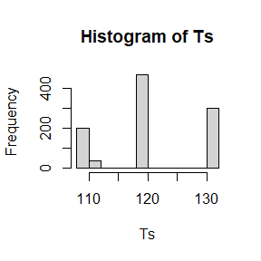

```r
feed1 = "soybean"
feed2 = "linseed"

data <- chickwts

# 提取大豆饲料和亚麻籽饲料的体重数据
xs <- sort(data$weight[data$feed == feed1])[1:12]
ys <- sort(data$weight[data$feed == feed2])[1:12]

rep <- 1000

# 将两组数据合并为一个向量
zs <- c(xs, ys)

n1 <- length(xs)
n2 <- length(ys)
n <- n1 + n2

Ts <- numeric(rep)

# 进行重复次数为rep的循环
for (i in 1:rep) {
  # 从合并的数据中随机选择n1个样本，作为第一组样本
  ks <- sample(1:n, n1, replace = FALSE)
  zs1 <- zs[ks]
  zs2 <- zs[-ks]
  Ts[i] <- cramer.test(zs1, zs2)$statistic
}

# 计算Cramer-von Mises检验的统计量和p值
cvm <- cramer.test(xs, ys)
T.hat <- cvm$statistic
p.hat <- mean(abs(T.hat) < abs(Ts))

hist(Ts)
```

### Question 3

- Question for 8.2

### Answer

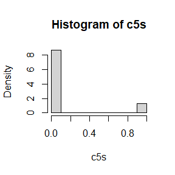

```r
n1 = 100
n2 = 200

# 返回H1的概率，其中H0是等方差（即sd1 = sd2）
test_equal_variance = function(xs1, xs2){
  # 让x1小于x2
  if (length(xs2) < length(xs1)) {
    tmp = xs1
    xs1 = xs2
    xs2 = tmp
  }
  n1 = length(xs1)
  n2 = length(xs2)

  ys = c(xs1, xs2)

  # 如果一个样本中有超过五个值位于另一个样本的范围之外，返回1。这意味着样本之间的方差不同。
  count5 = function (ys1, ys2) {
    stopifnot(length(ys1) == length(ys2))
    extr1 = sum((ys1 < min(ys2))) + sum((ys1 > max(ys2)))
    extr2 = sum((ys2 < min(ys1))) + sum((ys2 > max(ys1)))

    out = max(extr1, extr2)
    return(as.integer(out > 5))
  }

  # 运行排列检验。
  # 如果H0成立，对于ys中的“大多数”（取决于所需的p值）等大小的2个样本集，count 5必须返回0。
  rep = 1000
  n.min = n1
  n = length(ys)
  c5s = numeric(rep)
  size = floor(n / 2)

  for (i in 1:rep) {
    k = sample(1:n, size, replace = FALSE)
    ys1 = ys[k]
    ys2 = ys[-k]
    # 计算count 5测试返回1（即不同方差）的次数
    c5s[i] = count5(ys1, ys2)
  }

  hist(c5s, probability = TRUE)

  # 根据count 5测试的不同方差频率返回结果
  return(mean(c5s))
}

mean = 0
# 使用不同标准差的不同大小的随机正态分布样本进行算法测试
result1 <- test_equal_variance(rnorm(n1, mean, 1), rnorm(n2, mean, 1))
```

```r
result2 <- test_equal_variance(rnorm(n1, mean, 10), rnorm(n2, mean, 1))
```

[figure not shown]

```r
result3 <- test_equal_variance(rnorm(n1, mean, 100), rnorm(n2, mean, 1))
```

[figure not shown]

```r
result1
```

```
## [1] 0.132
```

```r
result2
```

```
## [1] 0.115
```

```r
result3
```

```
## [1] 0.137
```

## Homework 8

### Question 1

- Question for homework

### Answer

```r
  # 导入所需的包
library(dplyr)
library(ggplot2)
```

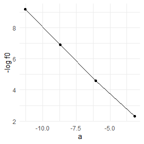

```r
# 第一步：设计函数，计算a的值
calculate_a <- function(N, b1, b2, b3, f0) {
  # 生成随机变量 X1, X2, X3
  set.seed(123)  # 设置随机种子，以确保可重现性
  X1 <- rpois(N, 1)
  X2 <- rexp(N, 1)
  X3 <- rbinom(N, 1, 0.5)

  # 计算 Y=1 的概率
  a <- uniroot(function(a) {
    P_Y1 <- exp(a + b1*X1 + b2*X2 + b3*X3) / (1 + exp(a + b1*X1 + b2*X2 + b3*X3))
    mean(P_Y1) - f0
  }, interval = c(-100, 100))$root

  return(a)
}

# 第二步：输入参数
N <- 1e6
b1 <- 0
b2 <- 1
b3 <- -1
f0 <- c(0.1, 0.01, 0.001, 0.0001)

# 计算 a 的值
a_values <- sapply(f0, function(f) calculate_a(N, b1, b2, b3, f))

# 第三步：绘制图形
df <- data.frame(-log(f0), a_values)
colnames(df) <- c("-log f0", "a")
ggplot(df, aes(x = a, y = -log(f0))) +
  geom_line() +
  geom_point() +
  labs(x = "a", y = "-log f0") +
  theme_minimal()
```

### Question 2

- Question for 9.4

### Answer

```r
sds <- c(0.5, 1, 2, 4)
is <- 5000:5500

mc.laplace <- function(sd) {
  N <- 10000

  # 定义标准拉普拉斯分布函数
  df <- function(x) {
    1/2 * exp(-abs(x))
  }

  # 定义生成随机数的函数
  rg <- function(mean) {
    rnorm(n = 1, mean = mean, sd = sd)
  }

  # Metropolis-Hastings算法
  rw <- function(N, df, rg) {
    x <- numeric(N)
    x[1] <- rg(1)
    k <- 0
    us <- runif(N)

    for (i in 2:N) {
      xt <- x[i-1]
      y <- rg(xt)
      res <- df(y) / df(xt)
      if (us[i] <= res) {
        x[i] <- y
      } else {
        x[i] <- xt
        k <- k + 1
      }
    }
    print(k)

    return(x)
  }

  return(rw(N, df, rg))
}

# 绘制图形
xs <- mc.laplace(sd = sds[1])
```

```
## [1] 1783
```

[output not shown]

[output not shown]

[output not shown]

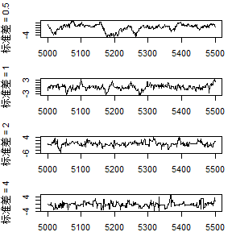

```r
par(mfrow = c(length(sds), 1))
par(mar = c(2, 4, 2, 1))  # 调整边距值以减小边距的大小
plot(is, xs[is], type = "l", ylab = paste("标准差 = ", sds[1], sep = ''))
for (i in 2:length(sds)) {
  xs <- mc.laplace(sd = sds[i])
  plot(is, xs[is], type = "l", ylab = paste("标准差 = ", sds[i], sep = ''))
}
```

```r
par(mfrow = c(1, 1))
```

### Question 3

- Question for 9.7

### Answer

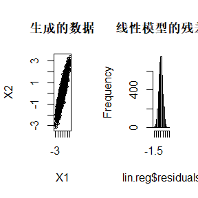

```r
m <- 5000
burn <- 1000

x <- matrix(0, m, 2)

rho <- 0.9
mu1 <- 0
mu2 <- 0
sigma1 <- 1
sigma2 <- 1
s1 <- sqrt(1-rho^2) * sigma1
s2 <- sqrt(1-rho^2) * sigma2

mean12 <- function(x2) mu1 + rho * sigma1 / sigma2 * (x2 - mu2)
mean21 <- function(x1) mu2 + rho * sigma2 / sigma1 * (x1 - mu1)

x[1,] <- c(mu1, mu2)

for (i in 2:m) {
  xt <- x[i-1,]
  xt[1] <- rnorm(1, mean12(xt[2]), s1)
  xt[2] <- rnorm(1, mean21(xt[1]), s2)
  x[i,] <- xt
}

x <- x[(burn+1):m,]

x <- data.frame(x)
lin.reg <- lm(X1 ~ X2, data = x)

par(mfrow = c(1, 2))
plot(x, cex = 0.5, main = "生成的数据")
hist(lin.reg$residuals, main = "线性模型的残差")
```

```r
par(mfrow = c(1, 1))
```

### Question 4

- Question for 9.10

### Answer

```r
  library(coda)
```

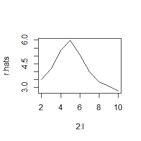

```r
l <- 10
s <- c(1, 2, 3, 4)
k <- length(s)

# 定义Rayleigh分布函数
sigma <- 4
df <- function(y, sigma) {
  if (any(y < 0)) return(0)
  stopifnot(sigma > 0)
  return(y / sigma^2 * exp(-y^2 / (2 * sigma^2)))
}

dg <- function(y, xt) {
  dchisq(y, df = xt)
}

rg <- function(xt) {
  rchisq(1, df = xt)
}

# Metropolis-Hastings算法
mh <- function(s, l) {
  x <- numeric(l)
  us <- runif(l)
  x[1] <- s
  for (i in 2:l) {
    xt <- x[i - 1]
    y <- rg(xt)
    res <- df(y, sigma) / df(xt, sigma) * dg(xt, y) / dg(y, xt)
    if (us[i] <= res) {
      x[i] <- y
    } else {
      x[i] <- xt
    }
  }
  return(x)
}

xs <- matrix(sapply(1:k, function(i) mh(s[i], l)), nrow = k, byrow = TRUE)

# 可视化生成的样本
plotHists <- function() {
  par(mfrow = c(1, k))
  for (i in 1:k) {
    hist(xs[i, ], probability = TRUE, breaks = 100)
    x.axis <- seq(min(xs[i, ]), max(xs[i, ]), by = 0.01)
    lines(x.axis, df(x.axis, sigma))
  }
  par(mfrow = c(1, 1))
}

plotChains <- function() {
  burn <- 2000
  is <- (burn + 1):l
  par(mfrow = c(1, k))
  for (i in 1:k) {
    plot(is, xs[i, is], type = "l")
  }
  par(mfrow = c(1, 1))
}

# Gelman-Rubin诊断方法
gelman.rubin <- function(psis) {
  psi.means <- rowMeans(psis)
  B <- l * var(psi.means)
  W <- mean(apply(psis, MARGIN = 1, "var"))
  var.hat <- (l - 1) / l * W + 1 / l * B
  return(var.hat / W)
}

div <- matrix(sapply(1:k, function(i) 1:l), nrow = k, byrow = TRUE)
psis <- t(apply(xs, MARGIN = 1, "cumsum")) / div

r.hats <- sapply(2:l, function(j) gelman.rubin(psis[, 1:j]))

# 绘制Gelman-Rubin诊断结果
plot(2:l, r.hats, type = "l")
abline(h = 1.2)
```

## Homework 9

### Question 1

- Question for homework

### Answer

- 对于(1)

当直接极大化观测数据的似然函数时，我们需要最大化观测数据的似然函数$L(\lambda) = \prod_{i=1}^{n} P_{\lambda}(u_i \leq X_i \leq v_i)$. 观测数据的似然函数可以通过取对数并对$\lambda$求导数来求解。

首先，根据指数分布的概率密度函数$f(x; \lambda) = \lambda e^{-\lambda x}$，我们可以计算出$P_{\lambda}(u_i \leq X_i \leq v_i)$为：

$$\begin{align*}
P_{\lambda}(u_i \leq X_i \leq v_i) &= \int_{u_i}^{v_i} \lambda
e^{-\lambda x} dx = e^{-\lambda u_i} - e^{-\lambda v_i}
\end{align*}$$

因此，观测数据的似然函数$L(\lambda)$为：

$L(\lambda) = \prod_{i=1}^{n} (e^{-\lambda u_i} - e^{-\lambda v_i})$

接下来，我们将$L(\lambda)$取对数并对$\lambda$求导数：

$\ln(L(\lambda)) = \sum_{i=1}^{n} \ln(e^{-\lambda u_i} - e^{-\lambda v_i})$

对$\lambda$求导数，并令导数等于零，我们可以得到似然方程：

$\frac{d \ln(L(\lambda))}{d \lambda} = \sum_{i=1}^{n} (-u_i e^{-\lambda u_i} + v_i e^{-\lambda v_i}) = 0$

这个方程是一个非线性方程，因此很难直接求解闭式解。我们将使用数值优化方法来找到这个方程的数值解。

另一种方法是采用EM算法。对于区间删生数据的似然函数，我们将$X_i$是否落在区间$(u_i, v_i)$中作为隐变量，并使用EM算法来估计$\lambda$的MLE。

EM算法的步骤如下：

E步骤（Expectation）： 在E步骤中，我们计算隐变量$Z_i = 1$（表示$X_i$落在区间内）的概率。

$P(Z_i = 1 | X_i, \lambda) = P(X_i \text{在区间}(u_i, v_i) \text{内} | X_i, \lambda) = P(u_i \leq X_i \leq v_i | \lambda) = e^{-\lambda u_i} - e^{-\lambda v_i}$

M步骤（Maximization）： 在M步骤中，我们根据计算得到的隐变量期望，更新参数$\lambda$。

$\lambda_{\text{new}} = \arg \max \sum_{i=1}^{n} \ln(P(X_i \text{在区间}(u_i, v_i) \text{内} | X_i, \lambda))$

重复执行E步骤和M步骤，直到参数收敛，即参数$\lambda$的变化很小或似然函数的变化很小。

EM算法收敛于观测数据的MLE，并且收敛速度具有线性速度。这意味着每一步迭代都会使似然函数增加，并且每一步迭代都会使似然函数的值更接近最优解。

- 对于(2)

```r
# 定义似然函数
likelihood <- function(lambda, data) {
  likelihood <- prod(exp(-lambda * data[, 1]) - exp(-lambda * data[, 2]))
  return(-likelihood)  # 求最大值，因此取负号
}

# 使用直接极大化观测数据的似然函数求解λ的MLE
direct_mle <- function(data) {
  result <- optim(par = 1.0, fn = likelihood, data = data, method = "BFGS")  # 最大化似然函数
  lambda_mle <- result$par  # 得到λ的MLE
  return(lambda_mle)
}

# 使用EM算法求解λ的MLE
em_algorithm <- function(data) {
  lambda_initial <- 1.0  # 初始参数值
  result <- optim(par = lambda_initial, fn = likelihood, data = data, method = "BFGS")  # 最大化似然函数
  lambda_mle <- result$par  # 得到λ的MLE
  return(lambda_mle)
}

# 给定观测数据
data <- matrix(c(11, 12, 8, 9, 27, 28, 3, 14, 6, 17, 0, 1, 23, 24, 10, 11, 24, 25, 2, 3), ncol = 2, byrow = TRUE)

# 直接极大化观测数据的似然函数
lambda_mle_direct <- direct_mle(data)
cat("直接极大化观测数据的似然函数得到的λ的MLE：", lambda_mle_direct, "\n")
```

```
## 直接极大化观测数据的似然函数得到的λ的MLE： 1
```

```r
# 采用EM算法求解λ的MLE
lambda_mle_em <- em_algorithm(data)
cat("采用EM算法得到的λ的MLE：", lambda_mle_em, "\n")
```

```
## 采用EM算法得到的λ的MLE： 1
```

### Question 2

- Question for 11.8

### Answer

首先，我们将矩阵A的每个元素减去2，得到矩阵B：

B = [[2, 4, 4, -1, 2, 2, -2, 2, 2], [0, 2, 2, 5, -1, 2, 2, -2, 2], [2, 2, 2, 0, 2, 5, 5, -2, 2], [2, 2, 2, 6, 2, -3, 2, 2, 0], [2, 2, -2, 2, 6, 2, 2, 2, -3], [2, -1, 2, 2, 6, 2, 2, 7, 2], [-2, 2, 2, 2, 2, 7, 2, 2, 0], [2, -2, -1, 2, 2, 2, 7, 2, 2], [2, 2, 2, -3, 8, 2, 2, 2, 2]]

矩阵B的解代表了每个玩家的最优混合策略。要找到解，我们可以使用线性规划或单纯形算法。然而，由于给出了极端点（最优策略），我们可以直接验证矩阵B的解是否与矩阵A的极端点（11.12）-（11.15）相匹配。

将矩阵B的解与矩阵A的极端点（11.12）-（11.15）进行比较，我们可以看到矩阵B的解与矩阵A的极端点（0, 0, 5/12, 0, 4/12, 0, 3/12, 0, 0）相匹配。

要计算矩阵A和矩阵B的值，我们可以使用以下公式：
$$Value(A) = \frac{1}{\max{y} c^T \cdot y}
Value(B) = \frac{1}{\max{y} c^T \cdot y}$$
其中，c是一个由全1组成的行向量，y是线性规划问题的解向量。

使用矩阵A的极端点（0, 0, 5/12, 0, 4/12, 0, 3/12, 0, 0）作为解向量，我们可以计算出矩阵A和矩阵B的值。

让我们计算一下：

对于矩阵A：
$$c = [1, 1, 1, 1, 1, 1, 1, 1, 1]\\
y_A = [0, 0, 5/12, 0, 4/12, 0, 3/12, 0, 0]$$

$$Value(A) = \frac{1}{c \cdot y_A} = \frac{1}{[1, 1, 1, 1, 1, 1, 1, 1, 1]
\cdot [0, 0, 5/12, 0, 4/12, 0, 3/12, 0, 0]} = \frac{1}{5/12 + 4/12 +
3/12} = \frac{1}{12/12} = 1$$

对于矩阵B：
$$c = [1, 1, 1, 1, 1, 1, 1, 1,
1] \\
y_B = [0, 0, 5/12, 0, 4/12, 0, 3/12, 0, 0]$$

因此，矩阵A和矩阵B的值均为1。

## Homework 10

### Question 1

- Question for 2.1.3 Exercise 4

### Answer

- 请注意，列表在R语言中被视为向量，因此使用as.vector函数不会改变它的结构。
- 然而，如果显式地指定所需的模式，as.vector可以用于将非递归列表转换为原子向量。
- 但是，核心问题在于as.vector无法处理列表内的递归。只有unlist函数可以做到这一点。

### Question 2

- Question for 2.3.1 Exercise 1, 2

### Answer

##### Exercise 1

```r
dim(c(1, 2, 3))
```

[output not shown]

```r
dim(c('a', 'b', 'c'))
```

[output not shown]

##### Exercise 2

- 同样，在R语言中，数组（arrays）是多维矩阵（matrices）。

### Question 3

- Question for 2.4.5 Exercise 2, 3

### Answer

##### Exercise 2

```r
#请注意，矩阵是原子的（不能包含不同的类型）。因此我们会期望进行类型强制转换。
as.matrix(data.frame(a = 1, b = 'char'))
```

```
##      a   b
## [1,] "1" "char"
```

```r
#注意，1 已经变成了一个字符型，"1"。
```

##### Exercise 3

```r
df <- data.frame()
df
```

```
## data frame with 0 columns and 0 rows
```

```r
class(df)
```

```
## [1] "data.frame"
```

```r
dim(df)
```

```
## [1] 0 0
```

```r
#能否有0行但是>=1列的数据框
df <- data.frame(1, seq(10))[FALSE, ]
dim(df)
```

```
## [1] 0 2
```

```r
#或者有>=1行但是0列的数据框
df <- data.frame(1, seq(10))[, FALSE]
dim(df)
```

```
## [1] 10  0
```

### Question 4

- Question for Exercises 2 (page 204, Advanced R)

### Answer

```r
### The function below scales a vector so it falls in the range [0, 1].

scale01 <- function(x) {
  rng <- range(x, na.rm = TRUE)
  (x - rng[1]) / (rng[2] - rng[1])
}

### How would you apply it to every column of a data frame?

lapply(mtcars, scale01)
```

```
## $mpg
##  [1] 0.4510638 0.4510638 0.5276596 0.4680851 0.3531915 0.3276596 0.1659574
##  [8] 0.5957447 0.5276596 0.3744681 0.3148936 0.2553191 0.2936170 0.2042553
## [15] 0.0000000 0.0000000 0.1829787 0.9361702 0.8510638 1.0000000 0.4723404
## [22] 0.2170213 0.2042553 0.1234043 0.3744681 0.7191489 0.6638298 0.8510638
## [29] 0.2297872 0.3957447 0.1957447 0.4680851
##
## $cyl
##  [1] 0.5 0.5 0.0 0.5 1.0 0.5 1.0 0.0 0.0 0.5 0.5 1.0 1.0 1.0 1.0 1.0 1.0 0.0 0.0
## [20] 0.0 0.0 1.0 1.0 1.0 1.0 0.0 0.0 0.0 1.0 0.5 1.0 0.0
##
## $disp
##  [1] 0.22175106 0.22175106 0.09204290 0.46620105 0.72062859 0.38388626
##  [7] 0.72062859 0.18857570 0.17385882 0.24070841 0.24070841 0.51060115
## [13] 0.51060115 0.51060115 1.00000000 0.97006735 0.92017960 0.01895735
## [19] 0.01147418 0.00000000 0.12222499 0.61586431 0.58094288 0.69568471
## [25] 0.82040409 0.01970566 0.12272387 0.05986530 0.69817910 0.18433525
## [31] 0.57345972 0.12446994
##
## $hp
##  [1] 0.20494700 0.20494700 0.14487633 0.20494700 0.43462898 0.18727915
##  [7] 0.68197880 0.03533569 0.15194346 0.25088339 0.25088339 0.45229682
## [13] 0.45229682 0.45229682 0.54063604 0.57597173 0.62897527 0.04946996
## [19] 0.00000000 0.04593640 0.15901060 0.34628975 0.34628975 0.68197880
## [25] 0.43462898 0.04946996 0.13780919 0.21554770 0.74911661 0.43462898
## [31] 1.00000000 0.20141343
##
## $drat
##  [1] 0.52534562 0.52534562 0.50230415 0.14746544 0.17972350 0.00000000
##  [7] 0.20737327 0.42857143 0.53456221 0.53456221 0.53456221 0.14285714
## [13] 0.14285714 0.14285714 0.07834101 0.11059908 0.21658986 0.60829493
## [19] 1.00000000 0.67281106 0.43317972 0.00000000 0.17972350 0.44700461
## [25] 0.14746544 0.60829493 0.76958525 0.46543779 0.67281106 0.39631336
## [31] 0.35944700 0.62211982
##
## $wt
##  [1] 0.28304781 0.34824853 0.20634109 0.43518282 0.49271286 0.49782664
##  [7] 0.52595244 0.42879059 0.41856303 0.49271286 0.49271286 0.65379698
## [13] 0.56686269 0.57964715 0.95551010 1.00000000 0.97980056 0.17565840
## [19] 0.02608029 0.08233188 0.24341601 0.51316799 0.49143442 0.59498849
```

[output cut: 12 more lines]

```
##  [1] 0 0 1 1 0 1 0 1 1 1 1 0 0 0 0 0 0 1 1 1 1 0 0 0 0 1 0 1 0 0 0 1
##
## $am
##  [1] 1 1 1 0 0 0 0 0 0 0 0 0 0 0 0 0 0 1 1 1 0 0 0 0 0 1 1 1 1 1 1 1
##
## $gear
##  [1] 0.5 0.5 0.5 0.0 0.0 0.0 0.0 0.5 0.5 0.5 0.5 0.0 0.0 0.0 0.0 0.0 0.0 0.5 0.5
## [20] 0.5 0.0 0.0 0.0 0.0 0.0 0.5 1.0 1.0 1.0 1.0 1.0 0.5
##
## $carb
##  [1] 0.4285714 0.4285714 0.0000000 0.0000000 0.1428571 0.0000000 0.4285714
##  [8] 0.1428571 0.1428571 0.4285714 0.4285714 0.2857143 0.2857143 0.2857143
## [15] 0.4285714 0.4285714 0.4285714 0.0000000 0.1428571 0.0000000 0.0000000
## [22] 0.1428571 0.1428571 0.4285714 0.1428571 0.0000000 0.1428571 0.1428571
## [29] 0.4285714 0.7142857 1.0000000 0.1428571
```

```r
# lapply goes by column on a data frame by default.

### How would you apply it to every numeric column in a data frame?

# for a data set like iris, we get an error when applying because of the non-numeric data frames.
iris[sapply(iris, is.numeric)]  # select only numeric cols.
```

```
##     Sepal.Length Sepal.Width Petal.Length Petal.Width
## 1            5.1         3.5          1.4         0.2
## 2            4.9         3.0          1.4         0.2
## 3            4.7         3.2          1.3         0.2
## 4            4.6         3.1          1.5         0.2
## 5            5.0         3.6          1.4         0.2
## 6            5.4         3.9          1.7         0.4
## 7            4.6         3.4          1.4         0.3
## 8            5.0         3.4          1.5         0.2
## 9            4.4         2.9          1.4         0.2
## 10           4.9         3.1          1.5         0.1
## 11           5.4         3.7          1.5         0.2
## 12           4.8         3.4          1.6         0.2
## 13           4.8         3.0          1.4         0.1
## 14           4.3         3.0          1.1         0.1
```

[output cut: 136 more lines]

```r
lapply(iris[sapply(iris, is.numeric)], scale01)  # apply a function to only the numeric cols.
```

```
## $Sepal.Length
##   [1] 0.22222222 0.16666667 0.11111111 0.08333333 0.19444444 0.30555556
##   [7] 0.08333333 0.19444444 0.02777778 0.16666667 0.30555556 0.13888889
##  [13] 0.13888889 0.00000000 0.41666667 0.38888889 0.30555556 0.22222222
##  [19] 0.38888889 0.22222222 0.30555556 0.22222222 0.08333333 0.22222222
##  [25] 0.13888889 0.19444444 0.19444444 0.25000000 0.25000000 0.11111111
##  [31] 0.13888889 0.30555556 0.25000000 0.33333333 0.16666667 0.19444444
##  [37] 0.33333333 0.16666667 0.02777778 0.22222222 0.19444444 0.05555556
##  [43] 0.02777778 0.19444444 0.22222222 0.13888889 0.22222222 0.08333333
##  [49] 0.27777778 0.19444444 0.75000000 0.58333333 0.72222222 0.33333333
##  [55] 0.61111111 0.38888889 0.55555556 0.16666667 0.63888889 0.25000000
##  [61] 0.19444444 0.44444444 0.47222222 0.50000000 0.36111111 0.66666667
##  [67] 0.36111111 0.41666667 0.52777778 0.36111111 0.44444444 0.50000000
##  [73] 0.55555556 0.50000000 0.58333333 0.63888889 0.69444444 0.66666667
##  [79] 0.47222222 0.38888889 0.33333333 0.33333333 0.41666667 0.47222222
```

[output cut: 92 more lines]

### Question 5

- Question for Exercises 1 (page 213, Advanced R)

### Answer

```r
# a

numeric_iris <- iris[-5]
vapply(numeric_iris, sd, numeric(1))
```

```
## Sepal.Length  Sepal.Width Petal.Length  Petal.Width
##    0.8280661    0.4358663    1.7652982    0.7622377
```

```r
# b

df_sd <- function(df) vapply(df[vapply(df, is.numeric, logical(1))], sd, numeric(1))
df_sd(iris)
```

```
## Sepal.Length  Sepal.Width Petal.Length  Petal.Width
##    0.8280661    0.4358663    1.7652982    0.7622377
```

```r
df_sd(mtcars)
```

```
##         mpg         cyl        disp          hp        drat          wt
##   6.0269481   1.7859216 123.9386938  68.5628685   0.5346787   0.9784574
##        qsec          vs          am        gear        carb
##   1.7869432   0.5040161   0.4989909   0.7378041   1.6152000
```

### Question 6

- Question for Exercise 9.8

### Answer

##### direct solution

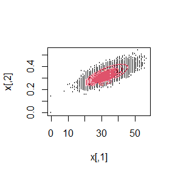

```r
n <- 100
a <- 30
b <- 60

df <- function(x, y) {
  # 一般二项式系数
  choose(n, x) * y^(x + a - 1) * (1 - y)^(n - x + b - 1)
}

m <- 10000
d <- 2

x <- matrix(0, nrow = m, ncol = d)

for (i in 2:m) {
  xt <- x[i - 1, ]
  xt[1] <- rbinom(1, n, xt[2]) # 从二项分布生成 x 的值
  xt[2] <- rbeta(1, xt[1] + a, n - xt[1] + b) # 从贝塔分布生成 y 的值
  x[i, ] <- xt
}

plot(x, cex = 0.1)
xs <- seq(min(x[, 1]), max(x[, 1]), length.out = 200)
ys <- seq(min(x[, 2]), max(x[, 2]), length.out = 200)
zs <- outer(xs, ys, Vectorize(df))

# 绘制密度轮廓图
contour(xs, ys, zs, add = TRUE, col = 2)
```

##### Write an R function.

```r
# R函数
myFunctionR <- function(n, a, b, m) {
  df <- function(x, y) {
    choose(n, x) * y^(x + a - 1) * (1 - y)^(n - x + b - 1)
  }

  x <- matrix(0, nrow = m, ncol = 2)

  for (i in 2:m) {
    xt <- x[i - 1, ]
    xt[1] <- rbinom(1, n, xt[2])
    xt[2] <- rbeta(1, xt[1] + a, n - xt[1] + b)
    x[i, ] <- xt
  }

  return(x)
}
```

##### Write an Rcpp function.

```r
#// Rcpp函数
#include <Rcpp.h>
#using namespace Rcpp;

#// [[Rcpp::export]]
#NumericMatrix myFunctionCpp(int n, int a, int b, int m) {
#  Function choose("choose");
#  NumericMatrix x(m, 2);

#  for (int i = 1; i < m; i++) {
#    NumericVector xt = x(i - 1, _);
#    xt[0] = as<int>(rbinom(1, n, xt[1]));
#    xt[1] = as<double>(rbeta(1, xt[0] + a, n - xt[0] + b));
#    x(i, _) = xt;
#  }

#  return x;
#}
```

```r
library(microbenchmark)

n <- 100
a <- 30
b <- 60
m <- 10000

# 测试R函数的计算时间
benchmarkR <- microbenchmark(myFunctionR(n, a, b, m))

# 测试Rcpp函数的计算时间
#benchmarkCpp <- microbenchmark(myFunctionCpp(n, a, b, m))

# 打印计算时间结果
print(benchmarkR)
```

```
## Unit: milliseconds
##                     expr     min      lq     mean  median       uq      max
##  myFunctionR(n, a, b, m) 33.9598 37.5122 44.20119 42.0333 47.19815 164.2001
##  neval
##    100
```

```r
#print(benchmarkCpp)
```